# Human Activity Recognition

Susana Arias Laso

## Introduction

The goal of this project is to implement a machine learning algorithm to predict how well a particular exercise was performed using data collected at different locations of an accelerometer. The “classe” feature in the dataset indicates the manner in which the exercise was done. Class A indicates that the exercise was performed exactly according to the specification, while the other four classes indicate some common mistake. Using accelerometers located on the belt, forearm, arm and dumbbell as recording devices, data from 6 participants was collected in order to quantify how well a particular activity was done.

The following libraries are needed to run the code.

```r
library(caret)
library(ggplot2)
library(dplyr)
library(magrittr)
library(tidyr)
library(doMC)

library(GGally)
```

Additionally, a seed is set before processing the data so the results can be easily reproduced.

```r
set.seed(2195324)
```

In order to save running time when implementing the prediction model, parallel processing is applied using half of the cores available.

```r
numCores <- detectCores()
registerDoMC(numCores / 2)
```

## Data Processing

```r
train_url =
    'https://d396qusza40orc.cloudfront.net/predmachlearn/pml-training.csv'
if (!file.exists("training.csv")) {
    download.file(url = train_url, destfile = 'training.csv')
}
```

Some missing entries in the dataset were identified and considered “NA” values before processing the data into training and test sets.

```r
training_data = read.csv(file = 'training.csv',
                         na.strings = c("NA", "", "#DIV/0!"))
```

In order to deal with the missing values, a boolean vector with the number of elements corresponding to the number of features in the dataset was created. Each component in the vector corresponds to the total number of NA values of a particular feature.

```r
na_col <- function(column_indx){
    sum(is.na(training_data[, column_indx]))
}

boolean <- function(indx){
    na_vector[indx] == 0
}
```

```r
indx_vector = 1:ncol(training_data)
na_vector = sapply(indx_vector, na_col)
boolean_vector = sapply(indx_vector, boolean)
```

The dataset in then evaluated on that boolean vector in order to keep only the features without missing values.

```r
data = training_data[, boolean_vector]
```

As features of interest for the prediction model we will keep only the variables that contain the original sensor readings. This corresponds to selecting the features that contain the Euler angles (roll, pitch and yaw) and the 3-axis coordinates of the accelerometer, gyroscope, and magnetometer readings for each sensor.

```r
data <- data %>%
    select(-contains("user"), -contains("timestamp"), -contains("window"),
           -contains("total")) %>%
    select(-starts_with("X")) %>%
    mutate("classe" = as.factor(classe))
```

The data is then separated into training and test sets, using 70% of the dataset to train the model.

```r
inTrain = createDataPartition(y = data$classe, p = 0.7, list = FALSE)
training = data[inTrain, ]
testing = data[-inTrain, ]
```

## Exploratory Data Analysis

Using the GGally library the correlation among the arm Euler angles is explored.

```r
data_pairs <- select(training,
                     contains("roll_arm"),
                     contains("pitch_arm"),
                     contains("yaw_arm"),
                     contains("classe"))
```

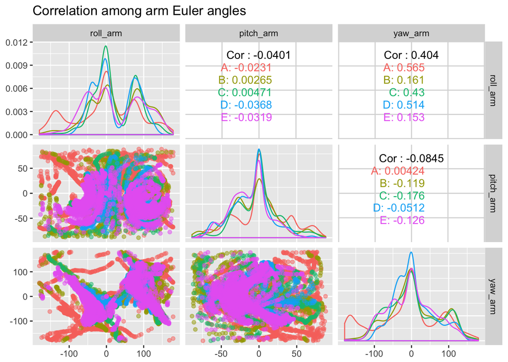

```r
ggallyDensityPlot <- function(data, mapping, ...){
    ggplot(data = data, mapping = mapping) +
    geom_density(mapping = aes_string(color = "classe"), fill = NA)
}

ggpairs(data_pairs, columns = c(1:3),
        mapping = ggplot2::aes(colour = classe),
        lower = list(continuous = wrap("points", alpha = 0.5)),
        diag = list(continuous = ggallyDensityPlot),
        title = 'Correlation among arm Euler angles'
        )
```

## Prediction Model

A random forest model was trained in order to predict how well each exercise was performed, i.e., the “classe” variable. A 10-fold cross validation of the model was implemented, using a tuning parameter of tuneLength = 8 which indicates the number of values to try for each hyperparameter. The process of running the model took about 40 minutes.

```r
rf_file = "./rf10foldCV.rds"

if (file.exists(rf_file)){
    rf10fold_cv <- readRDS("./rf10foldCV.rds")
} else {
    rf10fold_cv <- train(classe ~ ., data = training,
                    method = 'rf', prox = TRUE,
                    trControl = trainControl(method = "cv", number = 10),
                    tuneLength = 8)
}
```

The predictions of the model are evaluated on the test set, and shown in the form of an accuracy table, where the number of cases predicted correctly are indicated along the diagonal.

```r
pred <- predict(rf10fold_cv, testing)
accuracy_table <- table(pred, testing$classe)
accuracy_table
```

```
##
## pred    A    B    C    D    E
##    A 1673    5    0    0    0
##    B    1 1132    3    0    0
##    C    0    2 1022   13    3
##    D    0    0    1  950    0
##    E    0    0    0    1 1079
```

The model was 99.5% accurate on the test set, which indicates it will predict the feature “classe” with highly enough precision on unseen data.

```r
confusionMatrix(pred, testing$classe)$overall[1]
```

```
##  Accuracy
## 0.9950722
```

```r
acc <- function(index){
    accuracy_table[index, index] / sum(accuracy_table[, index])
}

classes <- c(1:5)
pred_by_class <- sapply(classes, acc)

for (i in seq(classes)) {
    cat("Class", classes[i], "precision: ", pred_by_class[i], "\n")
}
```

```
## Class 1 precision:  0.9994026
## Class 2 precision:  0.9938543
## Class 3 precision:  0.9961014
## Class 4 precision:  0.9854772
## Class 5 precision:  0.9972274
```

## Prediction Quiz

The following code applied the machine learning algorithm from the previous section on 20 different cases available in the testing data. The predictions are printed below.

```r
test_url =
    'https://d396qusza40orc.cloudfront.net/predmachlearn/pml-testing.csv'

if (!file.exists("test.csv")) {
    download.file(url = test_url, destfile = 'test.csv')
}

test_data = read.csv(file = 'test.csv', na.strings = c("NA", "", "#DIV/0!"))
```

```r
rf_predictions <- predict(rf10fold_cv, newdata = test_data)
rf_predictions
```

```
##  [1] B A B A A E D B A A B C B A E E A B B B
## Levels: A B C D E
```